# LIME example: Costa Rican snapper

Merrill Rudd

2016-11-02

# 1 Summary

The `LIME` package was developed to provide an estimate of stock status given the minimum requirements of (a) at least 1 year of length composition and (b) assumptions about biological parameters. The `LIME` package stands out from other length-based assessment methods in its estimation of annual fishing mortality and recruitment as a random effect, explicitly acknowledging process and observation error. Other methods overlook variation in the recruitment and/or fishing mortality processes. Another advantage of `LIME` is the integration of multiple years of length composition data, an abundance index, and/or catch time series, if available.

This vignette covers the steps in running the LIME method using an example.

The example in this vignette comes from the Costa Rican spotted snapper fishery. The data provided here is already massaged into the proper format. Please contact Merrill Rudd (merrillrudd@gmail.com) before using or distributing this dataset.

# 2 Installing and loading the package

Install the R package from github using devtools:

```r
devtools::install_github("merrillrudd/LIME")
```

Then load the library:

```r
library(LIME)
```

# 3 Example dataset

An example dataset for the LIME method is the Costa Rican spotted rose snapper. PRETOMA, a Costa Rica-based NGO, has been conducting surveys in of the snapper population in the Gulf of Nicoya for nine years (2007-2015). These surveys took length measurements from the catch, either on board vessels or at the dock. There is also a CPUE index based on the onboard observations of the soak time for the longlines/gillnets, and the number of hooks per longline and mesh size of gillnet, respectively. Since the majority of the catch was from longline gear, we only used the longline information for the CPUE time series. The length composition each year, however, was weighted based on the catch per gear, so as to use all of the length measurement information but not need to estimate two selectivity curves. The surveys, however, do not adequately account for the total catch from this fishery, therefore only the length composition over time, abundance index, and biological information are available for the stock assessment.

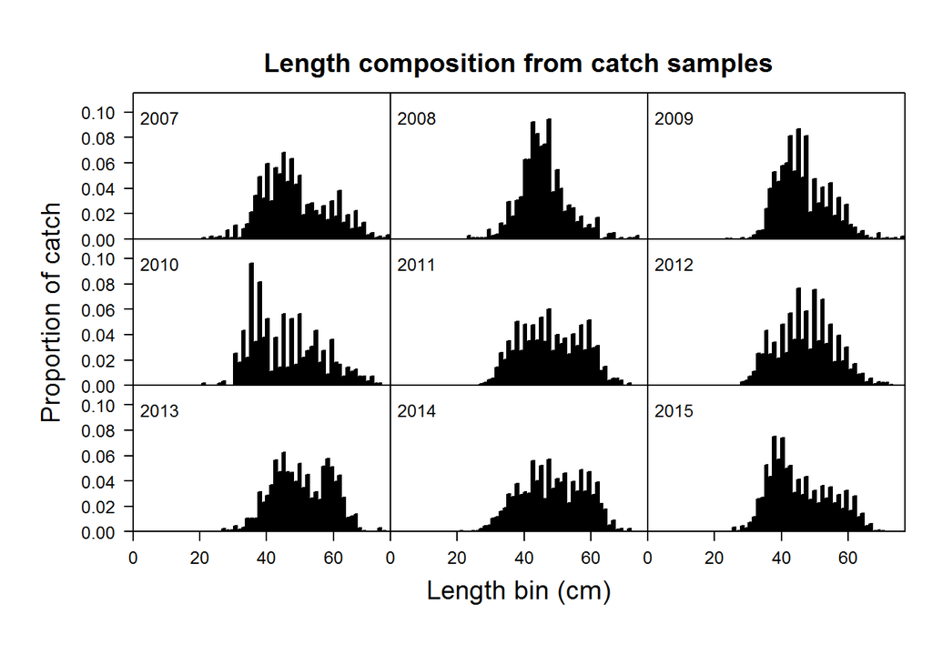

# 4 Running the LIME method

## 4.1 Compile inputs

### 4.1.1 Life history and starting values

Use the function `create_lh_list` to specify life history information for the stock you are assessing. The required inputs include:

- *vbk* – von Bertalanffy growth
- *linf* – von Bertlanffy asymptotic length
- *lwa* – length-weight scaling parameter
- *lwb* – length-weight allometric parameter
- *S50* – starting value for age or length at 50% selectivity (will be estimated in model)
- *selex_input* – specify whether *S50* is “age” or “length”
- *M50* – age or length at 50% maturity
- *maturity_input* – specify whether *M50* is “age” or “length”

You can also specify the naturality mortality rate (*M*), steepness (*h*), coefficient of variation around the growth curve (*CVlen*), and other values (including observation and process error) if some information is known. Otherwise, default values are specified for these parameters. See the help file `?create_lh_list` for default values of other life history parameters and the relationships used to derive life history information.

```r
lh <- create_lh_list(vbk=0.21, linf=64.58, lwa=0.0245, lwb=2.79, S50=30, selex_input="length", M50=34, maturity_input="length", binwidth=1, CVlen=0.1)
```

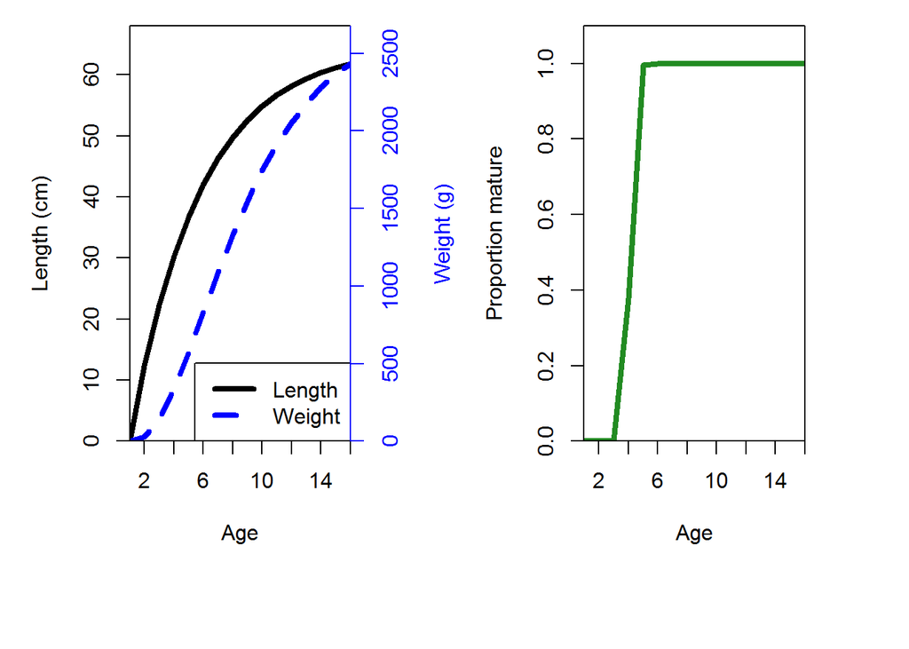

### 4.1.2 Observed data

In this example, the data is already included in the `snapper` object in the proper format along with the life history information.

To start from scratch with your own dataset, you will need a tagged list with:

- `years` – a vector of total years that you want to model. This can be in years (e.g. 2001-2010) or an index of years (1-10). It can also extend backward longer than the data available (e.g. 10 years before the first year of data).

```r
input_data <- list()
input_data$years <- snapper$years
input_data$years
```

```
##  [1] 1997 1998 1999 2000 2001 2002 2003 2004 2005 2006 2007 2008 2009 2010
## [15] 2011 2012 2013 2014 2015
```

```r
input_data$LF <- snapper$LF
input_data$LF[,1:20]
```

```
##    1 2 3 4 5 6 7 8 9 10 11 12 13           14 15 16 17           18 19
## 11 0 0 0 0 0 0 0 0 0  0  0  0  0 0.0000000000  0  0  0 0.0011933174  0
## 12 0 0 0 0 0 0 0 0 0  0  0  0  0 0.0000000000  0  0  0 0.0000000000  0
## 13 0 0 0 0 0 0 0 0 0  0  0  0  0 0.0000000000  0  0  0 0.0000000000  0
## 14 0 0 0 0 0 0 0 0 0  0  0  0  0 0.0000000000  0  0  0 0.0018115942  0
## 15 0 0 0 0 0 0 0 0 0  0  0  0  0 0.0000000000  0  0  0 0.0000000000  0
## 16 0 0 0 0 0 0 0 0 0  0  0  0  0 0.0000000000  0  0  0 0.0000000000  0
## 17 0 0 0 0 0 0 0 0 0  0  0  0  0 0.0000000000  0  0  0 0.0000000000  0
## 18 0 0 0 0 0 0 0 0 0  0  0  0  0 0.0000000000  0  0  0 0.0007453438  0
## 19 0 0 0 0 0 0 0 0 0  0  0  0  0 0.0002672029  0  0  0 0.0000000000  0
##              20
## 11 0.0023866348
## 12 0.0025732727
## 13 0.0005949621
## 14 0.0000000000
## 15 0.0004196391
## 16 0.0000000000
## 17 0.0000000000
## 18 0.0000000000
## 19 0.0002672029
```

If there is only one year of length composition data available, the data should still be in the same matrix format with column and row names in the same structure as with multiple years. Note that the data may need to be manipulated to have length bins along the columns and the year on the rows.

```r
## alternate data setup - 1 year of length composition data
LF1 <- t(as.matrix(snapper$LF[nrow(snapper$LF),]))
rownames(LF1) <- rownames(snapper$LF)[nrow(snapper$LF)]
#input_data$LF <- LF1
LF1
```

```
##    1 2 3 4 5 6 7 8 9 10 11 12 13           14 15 16 17 18 19           20
## 19 0 0 0 0 0 0 0 0 0  0  0  0  0 0.0002672029  0  0  0  0  0 0.0002672029
##              21          22          23          24          25
## 19 0.0002672029 0.003655809 0.001068811 0.004682105 0.003206434
##             26         27         28         29         30         31
## 19 0.007129446 0.01198161 0.02605833 0.02677491 0.05252353 0.04334149
##            32         33         34         35         36       37
## 19 0.07523577 0.05674415 0.07371758 0.04966933 0.05186157 0.030625
##            38         39         40         41         42        43
## 19 0.04115516 0.02907022 0.04312865 0.02529898 0.03263482 0.0224994
##            44        45         46         47        48         49
## 19 0.03642409 0.0263616 0.03540991 0.02251151 0.0291854 0.01829089
##            50         51         52         53         54          55
## 19 0.03242816 0.01659672 0.02804367 0.01164741 0.01465338 0.004833871
##             56           57          58           59           60
## 19 0.006449198 0.0009837804 0.001615327 0.0009837804 0.0002246873
##              61           62 63 64 65 66 67 68 69 70 71 72 73 74 75 76 77
## 19 0.0002246873 0.0002672029  0  0  0  0  0  0  0  0  0  0  0  0  0  0  0
```

Other input options include:

- `I_t` – a vector with abundance index each year, named with the index representing the year from which it came (e.g. index from some years but not all when modeling years 1-19). The following example is the abundance index derived from the snapper dataset. Note that an abundance index is not available in year 15 so that year is skipped in the vector.

```r
input_data$I_t <- snapper$I_t
input_data$I_t
```

```
##          11          12          13          14          16          17
## 0.011104135 0.015225879 0.009087462 0.001913120 0.030111474 0.007549830
```

- `C_t` – a vector of catch data each year, named with the index representing the year from which it came (e.g. catch data from years 10-19 when modeling years 1-19). The following example demonstrates a hypothetical catch of 50 units each year for years 10-19. Note that the catch data does not have to be available every year, and so the year labels would skip the years where the data are missing.

```r
#input_data$C_t <- C_t
C_t <- rep(50, length(10:19))
names(C_t) <- 10:19
C_t
```

```
## 10 11 12 13 14 15 16 17 18 19
## 50 50 50 50 50 50 50 50 50 50
```

### 4.1.3 Combine to input list

Use the function `create_inputs` to make one list that includes the life history information and observed data inputs.

The `param` and `val` arguments can be used to make last-minute adjustments to the input values. For example, if you want to try running the model with a steepness `h` fixed below 1, you would specify `param="h"` and `val=0.7` (for example). You can also add a concatenated string of parameter names and values if you want to adjust several values at the same time, for example `param=c("h", "CVlen")` and `val=c(0.7, 0.05)`. The `param` names must match the names of the outputs from `create_lh_list` and `input_data`.

```r
inits <- create_inputs(lh_list=lh, data_avail_list=input_data, param=FALSE, val=FALSE)
names(inits)
```

```
##  [1] "vbk"         "linf"        "t0"          "binwidth"    "CVlen"
##  [6] "SigmaC"      "SigmaI"      "SigmaR"      "SigmaF"      "R0"
## [11] "lwa"         "lwb"         "S50"         "h"           "qcoef"
## [16] "M"           "F1"          "AgeMax"      "mids"        "highs"
## [21] "lows"        "S_a"         "L_a"         "W_a"         "M50"
## [26] "Mat_a"       "Fequil"      "Frate"       "Fmax"        "years"
## [31] "LF"          "I_t"         "log_sigma_C" "log_sigma_I" "log_CV_L"
## [36] "Nyears"
```

Your named list `inits` is now ready to plug in assumed values, starting values for parameters to be estimated, and data time series to fit the model.

## 4.2 Run model

You will use the `runModel` function to run the LIME method. The arguments for applying the LIME method to real data (as opposed to simulation) are:

```r
run <- runModel(modpath=<path>, est_sigma="log_sigma_R", data_avail="LC", lh_list=lh, input_data=input_data, rewrite=TRUE, start_f=0, simulation=FALSE, itervec=NULL)
```

## 4.3 Check results

Do your results make sense? Check out the tagged list of outputs saved in `Report.rds` and the standard errors in `Sdreport.rds` saved in the results directory. Compare the output from different models (e.g. estimating or fixing `CVlen`).

Files saved in output directory:

- `obsData.rds` – observed data
- `Inputs1.rds` and `Inputs2.rds` – inputs into TMB. Check that these look right. The `Inputs2.rds` are the most recent inputs after an initial run that estimated the standard error for the recruitment deviation used to develop the bias adjustment term.
- `Report.rds` – tagged list of outputs from the population model.
- `Sdreport.rds` – standard deviations for a select list of estimated and derived parameters from the population model.
- `Derived_quants.rds` – list of derived quantities such as MSY and SPR-based reference points.
- `df.csv` – this shows the final gradient and estimated values for each parameter. Check that the final gradients are less than 0.01. If the model did not converge, there will be a text file called `high_final_gradient.txt` to flag the non-convergence.

## 4.4 Run sensitivity analyses

Run your analysis with a series of alternate values for the inputs in `create_lh_list` that have uncertainty. For example, you may have assumed natural mortality `M` was approximately 1.5*vbk, the default relationship. Try running the model with a series of possible values for `M`. Create a likelihood profile for each to determine if there is a better fit to the data given the alternate value.